# Confidence Interval for a Population Proportion

Yuanting Lu

11/03/2025

### Point Estimator

The sample proportion $\widehat{p}$ is a **point estimator** for the true population proportion $p$. The standard deviation of $\widehat{p}$ is called the **standard error** of $\widehat{p}$, often approximated by
$$se(\widehat{p})=\sqrt{\dfrac{\widehat{p}(1-\widehat{p})}{n}}.$$

Standard error meansures the **spread** of the sampling distribution of $\widehat{p}$.

**Ross 8.3** A school district is trying to determine its students’ reaction to a proposed dress code. To do so, the school selected a random sample of 50 students and questioned them. If 20 were in favor of the proposal, then

1. Estimate the proportion of all students who are in favor.
2. Estimate the standard error of the estimate.

### Interval Estimator

> “Sacrificing some precision in our estimate, in moving from a point to an interval, has resulted in increased confidence that our assertion is correct. The purpose of using an interval estimator rather than a point estimator is to have some guarantee of capturing the parameter of interest.” – Casella and Berger, *Statistical Inference*, 2nd edition, p. 418.

A 95% confidence interval for a population proportion $p$ is
$$\left(\widehat{p} -
1.96\sqrt{\dfrac{\widehat{p}(1-\widehat{p})}{n}}, \quad\widehat{p} +
1.96\sqrt{\dfrac{\widehat{p}(1-\widehat{p})}{n}}\right).$$

**Example 1.** Of the 1005 people participated in a survey, 728 people (72.4%) are in favor of candidate A. Based on the survey, we are 95% confident that the proportion of voters who support candidate A is between 0.697 and 0.752.

In general, a $100(1-\alpha)$% confidence interval for a population proportion $p$ is
$$\left(\widehat{p} -
z_{\alpha/2}\sqrt{\dfrac{\widehat{p}(1-\widehat{p})}{n}},
\quad\widehat{p} +
z_{\alpha/2}\sqrt{\dfrac{\widehat{p}(1-\widehat{p})}{n}}\right).$$

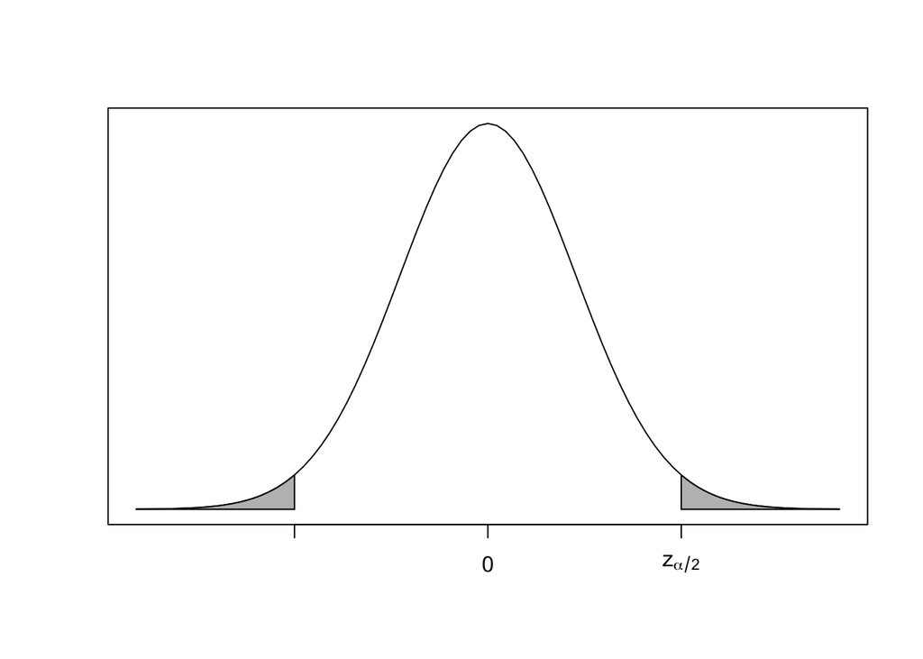

**Example 2.** Of the 1005 people participated in a survey, 728 people (72.4%) are in favor of candidate A. Based on the survey,

1. Find the 99% confidence interval for the proportion of people who are in favor of candidate A.
2. Find the 90% confidence interval for the proportion of people who are in favor of candidate A.

**Ross 8.15** Out of a random sample of 100 students at a university, 82 stated that they were nonsmokers. Based on this, construct a 99% confidence interval estimate of the proportion of all the students at the university who are nonsmokers.

### Margin of Error

Half the width of a confidence interval is called the **margin of error**.

$$MOE =
z_{\alpha/2}\sqrt{\dfrac{\widehat{p}(1-\widehat{p})}{n}}.$$

The largest possible value for $\widehat{p}(1-\widehat{p})$ is 0.25. Therefore, the following can be used to estimate MOE.

$$MOE\approx
z_{\alpha/2}\sqrt{\dfrac{0.25}{n}}=z_{\alpha/2}\dfrac{0.5}{\sqrt
n}.$$

Furthermore, 95% is the most commonly used confidence level. Thus, if confidence level is not provided, by default, we use $z_{\alpha/2}=z_{0.025}=1.96$.

**Example 3.** How large a sample is needed to ensure that the length of the 90% confidence interval estimate of $p$ is less than 0.01?

**Ross 8.16.** On December 24, 1991, The New York Times reported that a poll indicated that 46 percent of the population was in favor of the way that President Bush was handling the economy, with a margin of error of $\pm 3$% What does this mean? Can we infer how many people were questioned?